# Econometrics Session2 – R Regressions

Now we are trying to get ready for running regressions in R and for collecting nice output from the regressions.

First, let’s load (and potentially install) some packages.

```r
#install.packages("stargazer")
#install.packages("dplyr")
#install.packages("GGally")
#install.packages("ggplot2")
library(stargazer)
library(dplyr)
library(GGally)
library(ggplot2)
```

Next, we load data from the American Time Use Survey.

```r
# we want to read in the dataset "atus.csv", where all string variables are automatically transformed to factor variables
atus <- read.csv("atus.csv", stringsAsFactors = TRUE)
```

Here is a description of the variables in the data set:

- `tuyear` survey year
- `occup_code` occupation code where individual works
- `ind_code` industry code where individual works
- `labor_status` labor force status
- `ptft` whether the respondent works part-time or full-time
- `work_class` class of work
- `hourly_wage` hourly earnings at main job
- `work_hrs_week` number of hours worked per week
- `mult_jobs` had more than 1 jobs in 7 days prior to interview
- `partner_hh` presence of respondent’s spouse/unmarried partner in the household
- `hh_size` number of people living in household
- `hh_child` presence of household children aged < 18

We would like to describe the variables that determine the hourly wage of an individual. To do so, we follow the 6 steps from class.

1. Look at the data

```r
view(atus)
```

```
Error in view(atus) : could not find function "view"
```

Anything that looks weird?

2. Summary statistics

```r
summary(atus)
```

```
     tuyear            occup_code               ind_code               labor_status   ptft         work_class
 Min.   :2003   service     :11751   edu_health_svcs:13253   employed-absent : 2125   FT:39463   govt   : 8226
 1st Qu.:2005   office_admin: 9601   trade          : 8136   employed-at work:51463   PT:14125   private:45362
 Median :2009   professional: 9349   manuf          : 6915
 Mean   :2009   production  : 5013   hospitality    : 5305
 3rd Qu.:2012   sales       : 4701   prof_biz_svcs  : 4321
 Max.   :2016   transport   : 3843   construction   : 3221
                (Other)     : 9330   (Other)        :12437
  hourly_wage    work_hrs_week    mult_jobs     partner_hh       hh_size       hh_child
 Min.   : 1.10   Min.   :  0.00   no :48936   cohabit: 2494   Min.   : 1.000   no :25273
 1st Qu.: 9.40   1st Qu.: 32.00   yes: 4652   none   :25517   1st Qu.: 2.000   yes:28315
 Median :13.00   Median : 40.00               spouse :25577   Median : 3.000
 Mean   :15.76   Mean   : 37.22                               Mean   : 2.966
 3rd Qu.:19.00   3rd Qu.: 40.00                               3rd Qu.: 4.000
 Max.   :99.99   Max.   :160.00                               Max.   :13.000
```

Do you observe something strange?

Answer: Several Variables are not numeric.

```r
str(atus)
```

```
'data.frame':   53588 obs. of  12 variables:
 $ tuyear       : int  2003 2003 2003 2003 2003 2003 2003 2003 2003 2003 ...
 $ occup_code   : Factor w/ 10 levels "construction",..: 7 9 9 5 9 5 8 8 9 6 ...
 $ ind_code     : Factor w/ 13 levels "agric_forestry_hunting",..: 3 3 3 4 3 9 5 12 11 2 ...
 $ labor_status : Factor w/ 2 levels "employed-absent",..: 1 1 2 2 2 2 2 2 2 2 ...
 $ ptft         : Factor w/ 2 levels "FT","PT": 2 2 1 1 1 1 2 2 2 1 ...
 $ work_class   : Factor w/ 2 levels "govt","private": 1 2 2 2 2 2 2 2 1 2 ...
 $ hourly_wage  : num  22 12.5 9.5 14 12 7.42 7.5 7 7 8.75 ...
 $ work_hrs_week: int  30 12 40 40 40 35 30 25 12 50 ...
 $ mult_jobs    : Factor w/ 2 levels "no","yes": 1 1 1 1 1 1 1 1 1 1 ...
 $ partner_hh   : Factor w/ 3 levels "cohabit","none",..: 3 3 2 3 3 2 3 2 2 1 ...
 $ hh_size      : int  3 2 5 5 6 2 3 6 3 3 ...
 $ hh_child     : Factor w/ 2 levels "no","yes": 1 1 2 2 2 2 2 2 2 1 ...
```

```r
levels(atus$partner_hh)
```

```
[1] "cohabit" "none"    "spouse"
```

3. Scatterplots and 4. Correlations

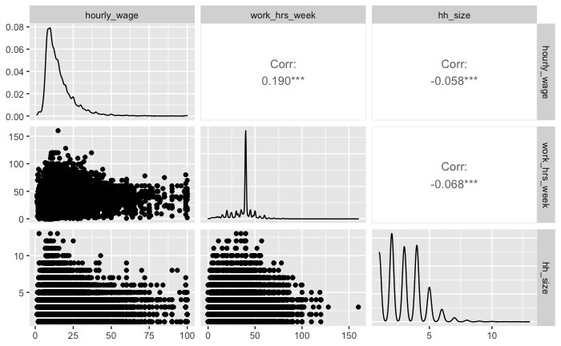

```r
ggpairs(atus[,c("hourly_wage", "work_hrs_week", "hh_size")])
```

5. Model

Let’s discuss which variables should enter the model. [Open discussion]

6. Estimate and Assess Model

[Use variables that you determined in the discussion.]

```r
model1 <- lm(hourly_wage ~ hh_size + work_hrs_week + occup_code, data = atus)

summary(model1)
```

```
Call:
lm(formula = hourly_wage ~ hh_size + work_hrs_week + occup_code,
    data = atus)

Residuals:
    Min      1Q  Median      3Q     Max
-23.090  -4.539  -1.487   2.689  88.045

Coefficients:
                                   Estimate Std. Error t value Pr(>|t|)
(Intercept)                        15.02852    0.22221  67.632   <2e-16 ***
hh_size                            -0.22132    0.02429  -9.112   <2e-16 ***
work_hrs_week                       0.11258    0.00310  36.321   <2e-16 ***
occup_codefarming_forestry_fishing -8.97918    0.44332 -20.254   <2e-16 ***
occup_codeinstall_repair_maint      0.46097    0.23677   1.947   0.0516 .
occup_codemgmt_biz_finance          2.22267    0.21224  10.473   <2e-16 ***
occup_codeoffice_admin             -4.24679    0.18107 -23.454   <2e-16 ***
occup_codeproduction               -4.18540    0.19846 -21.090   <2e-16 ***
occup_codeprofessional              4.44224    0.18166  24.454   <2e-16 ***
occup_codesales                    -7.19444    0.20281 -35.473   <2e-16 ***
occup_codeservice                  -7.03905    0.17809 -39.526   <2e-16 ***
occup_codetransport                -4.89227    0.20942 -23.361   <2e-16 ***
---
Signif. codes:  0 ‘***’ 0.001 ‘**’ 0.01 ‘*’ 0.05 ‘.’ 0.1 ‘ ’ 1

Residual standard error: 8.542 on 53576 degrees of freedom
Multiple R-squared:  0.2315,    Adjusted R-squared:  0.2313
F-statistic:  1467 on 11 and 53576 DF,  p-value: < 2.2e-16
```

Does the model make sense? Are the signs and significance levels as you expected? Interpret the coefficients.

Look at the adjusted R2.

Now let’s learn about a packages that simplifies the comparison of different models and helps to produce nice regression output.

```r
# for summary statistics
stargazer(atus, type = 'text', digits = 1)
```

```
===================================================================
Statistic       N     Mean   St. Dev.  Min  Pctl(25) Pctl(75)  Max
-------------------------------------------------------------------
tuyear        53,588 2,008.8   4.1    2,003  2,005    2,012   2,016
hourly_wage   53,588  15.8     9.7      1     9.4       19     100
work_hrs_week 53,588  37.2     12.4     0      32       40     160
hh_size       53,588   3.0     1.5      1      2        4      13
-------------------------------------------------------------------
```

```r
#for regression output
stargazer(model1, type = 'text')
```

[output not shown]

```
================================================================
                                        Dependent variable:
                                   -----------------------------
                                            hourly_wage
----------------------------------------------------------------
hh_size                                      -0.221***
                                              (0.024)

work_hrs_week                                0.113***
                                              (0.003)

occup_codefarming_forestry_fishing           -8.979***
                                              (0.443)

occup_codeinstall_repair_maint                0.461*
                                              (0.237)

occup_codemgmt_biz_finance                   2.223***
                                              (0.212)

occup_codeoffice_admin                       -4.247***
                                              (0.181)

occup_codeproduction                         -4.185***
                                              (0.198)

occup_codeprofessional                       4.442***
                                              (0.182)

occup_codesales                              -7.194***
                                              (0.203)

occup_codeservice                            -7.039***
                                              (0.178)

occup_codetransport                          -4.892***
                                              (0.209)

Constant                                     15.029***
                                              (0.222)

----------------------------------------------------------------
Observations                                  53,588
R2                                             0.231
Adjusted R2                                    0.231
Residual Std. Error                     8.542 (df = 53576)
F Statistic                        1,466.816*** (df = 11; 53576)
================================================================
Note:                                *p<0.1; **p<0.05; ***p<0.01
```

You can experiment with different model specifications. Does the R2 change? Do the coefficients change? What is your preferred model specification?

```r
model2 <- lm(hourly_wage ~ hh_size + work_hrs_week + ptft , data = atus)
model3 <- lm(hourly_wage ~ hh_size + work_hrs_week + ptft + occup_code, data = atus)
stargazer(model1, model2, model3, type = 'text')
```

[output not shown]

```
=========================================================================================================================
                                                                    Dependent variable:
                                   --------------------------------------------------------------------------------------
                                                                        hourly_wage
                                                (1)                         (2)                          (3)
-------------------------------------------------------------------------------------------------------------------------
hh_size                                      -0.221***                   -0.261***                    -0.205***
                                              (0.024)                     (0.027)                      (0.024)

work_hrs_week                                0.113***                     0.070***                    0.068***
                                              (0.003)                     (0.005)                      (0.005)

occup_codefarming_forestry_fishing           -8.979***                                                -8.837***
                                              (0.443)                                                  (0.443)

occup_codeinstall_repair_maint                0.461*                                                   0.467**
                                              (0.237)                                                  (0.236)

occup_codemgmt_biz_finance                   2.223***                                                 2.249***
                                              (0.212)                                                  (0.212)

occup_codeoffice_admin                       -4.247***                                                -4.199***
                                              (0.181)                                                  (0.181)

occup_codeproduction                         -4.185***                                                -4.194***
                                              (0.198)                                                  (0.198)

occup_codeprofessional                       4.442***                                                 4.545***
                                              (0.182)                                                  (0.182)

occup_codesales                              -7.194***                                                -6.977***
                                              (0.203)                                                  (0.203)

occup_codeservice                            -7.039***                                                -6.846***
                                              (0.178)                                                  (0.178)

occup_codetransport                          -4.892***                                                -4.741***
                                              (0.209)                                                  (0.209)

ptftPT                                                                   -2.816***                    -1.704***
                                                                          (0.146)                      (0.132)

Constant                                     15.029***                   14.660***                    17.003***
                                              (0.222)                     (0.240)                      (0.269)

-------------------------------------------------------------------------------------------------------------------------
Observations                                  53,588                       53,588                      53,588
R2                                             0.231                       0.045                        0.234
Adjusted R2                                    0.231                       0.045                        0.234
Residual Std. Error                     8.542 (df = 53576)           9.522 (df = 53584)          8.528 (df = 53575)
F Statistic                        1,466.816*** (df = 11; 53576) 835.485*** (df = 3; 53584) 1,362.613*** (df = 12; 53575)
=========================================================================================================================
Note:                                                                                         *p<0.1; **p<0.05; ***p<0.01
```

# Regression formulas:

Let’s learn about additional options how to specify regression models.

- `outcome ~ independent_variable1 + independent_variable2`
- factor variables are automatically turned into dummies `y ~ x + factor(z)` (We have seen this with the `occup_code`)
- interactions: `y ~ x*z`
- only interactions (not individual): `y ~ x:z`
- full interaction sets: `y ~ (x1 + x2 + x3)^2`
- can use functions: `ln(y) ~ x`
- Use `I()` if you want to do calculations with variables first: `I(y == 1) ~ I(x^2)`
- With many `x` variables can abbreviate `y ~ .`

Exercise: Try several alternative specifications: log hourly wage, interactions between `ptft` and working hours, etc… How are the coefficients interpreted?

# Prediction

```r
model_final <- lm(hourly_wage ~ hh_size + work_hrs_week + ptft + occup_code , data = atus)


new_data <- data.frame(hh_size = 3, work_hrs_week = 40, occup_code = "professional", ptft = "FT")

predicted_hourly_wage <- predict(model_final, newdata = new_data)
```